# Final Project:

# 9. Additional Context Maps

Below are a series of maps that illustrate where rent burden and demographics are distributed throughout Philadelphia.

## 9.1 Rent Burden by Census Tract

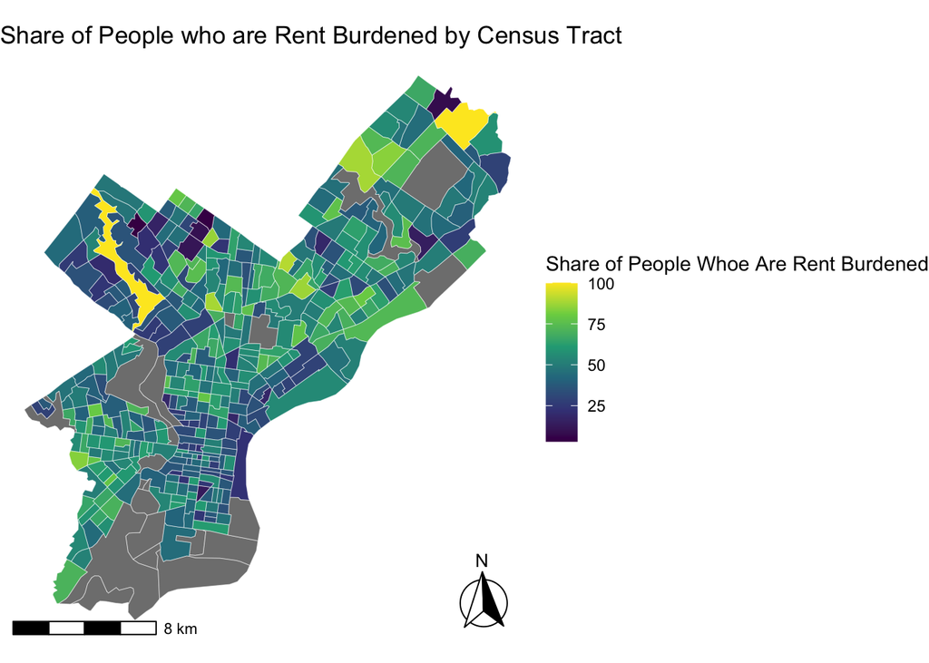

```r
##Maps rent burden
library(ggspatial)

philly_rent_burden1 <- left_join(census_crs, philly_rent_burden,  by = "GEOID")

rent_map <- ggplot(philly_rent_burden1) +
  geom_sf(aes(fill = share_rent_burdened), color = "white", linewidth = 0.1) +
  scale_fill_viridis_c() +

  # --- North arrow ---
  annotation_north_arrow(
    location = "br",   # top right
    which_north = "true",
    style = north_arrow_fancy_orienteering
  ) +

  # --- Scale bar ---
  annotation_scale(
    location = "bl",   # bottom left
    width_hint = 0.3
  ) +

  labs(
    title = "Share of People who are Rent Burdened by Census Tract",
    fill = "Share of People Whoe Are Rent Burdened"
  ) +
  theme_void()

rent_map
```

```r
philly_race1 <- left_join(census_crs, philly_race,  by = "GEOID")
```

## 9.2 Black Population Share by Census Tract

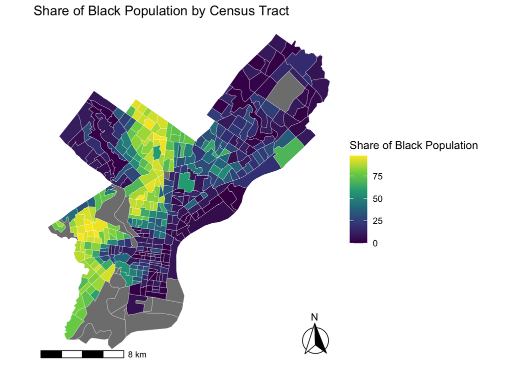

```r
black <- ggplot(philly_race1) +
  geom_sf(aes(fill = share_black), color = "white", linewidth = 0.1) +
  scale_fill_viridis_c() +

  # --- North arrow ---
  annotation_north_arrow(
    location = "br",   # top right
    which_north = "true",
    style = north_arrow_fancy_orienteering
  ) +

  # --- Scale bar ---
  annotation_scale(
    location = "bl",   # bottom left
    width_hint = 0.3
  ) +

  labs(
    title = "Share of Black Population by Census Tract",
    fill = "Share of Black Population"
  ) +
  theme_void()

black
```

## 9.3 Hispanic Population Share by Census Tract

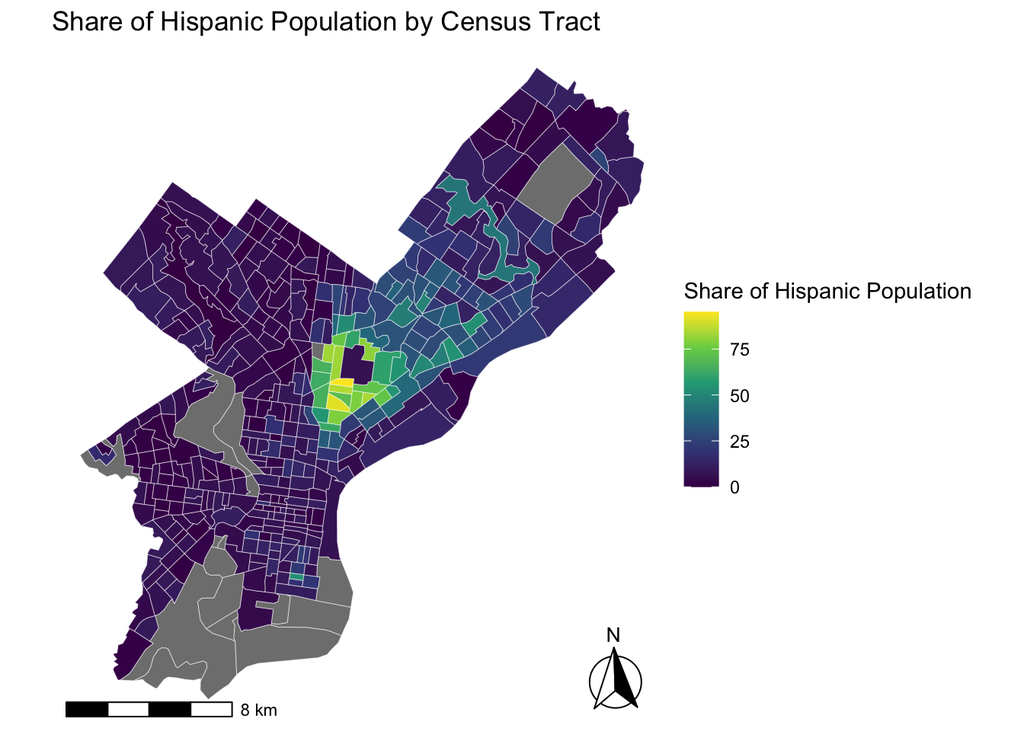

```r
hispanic <- ggplot(philly_race1) +
  geom_sf(aes(fill = share_hispanic), color = "white", linewidth = 0.1) +
  scale_fill_viridis_c() +

  # --- North arrow ---
  annotation_north_arrow(
    location = "br",   # top right
    which_north = "true",
    style = north_arrow_fancy_orienteering
  ) +

  # --- Scale bar ---
  annotation_scale(
    location = "bl",   # bottom left
    width_hint = 0.3
  ) +

  labs(
    title = "Share of Hispanic Population by Census Tract",
    fill = "Share of Hispanic Population"
  ) +
  theme_void()

hispanic
```

# 10. Discussion

## 10.1 Feedback Consideration and Implementation

The feedback our team received was implemented into our analysis; however, diagnostics informed our decisions of preserving the original methodology that was developed. The suggestion of turning eviction filings into a rate by dividing the count of evictions by renter occupied households was considered and became the dependent variable. As per Dr. Lassitter’s recommendation of utilizing a Poisson, the dependent variable was tested with the baseline model including month and season. Diagnostics were then completed and severe under dispersion was detected with a result of 0.005. As a result, the decision to preserve weekly count was decided upon.

## 10.2 Policy Implications

Our model, which examines and predicts weekly eviction filings, not only identifies trends but also serves as an early warning system, enabling timely and targeted policy interventions to prevent eviction spikes. Such interventions may include measures like temporary eviction moratoriums during periods of elevated risk, such as winter months, when conditions in cities like Philadelphia, characterized by cold temperatures and snow, can increase vulnerability and the risk of homelessness. By anticipating periods of heightened risk, policymakers can act proactively rather than reactively, reducing both the incidence and severity of housing instability. However, because the model performs more accurately in higher-income areas, policymakers should exercise caution when applying its predictions to lower-income communities, where eviction patterns may be less predictable and where the need for intervention is often greatest. This limitation highlights the importance of supplementing model predictions with local knowledge and additional data to ensure that policy responses remain both effective and equitable

## 10.3 Limitations and Ethical Considerations

One potential limitation of this model is that we have data from a limited time period. This is because data from 2020 to 2022 was omitted due to potential variability following the aftermath of COVID 19. Therefore, our temporal lags are less robust than lags that would have included more weekly observations. Additionally, this reduced the size of our overall observations which could have reduced the predictive power of the model by not having an adequate train/split pool. Additionally, reasons for eviction patterns usually present themselves more clearly at the neighborhood level, but in this analysis we are using the census tracts which may not be the best geographical unit to understand the varying factors that contribute to dynamic neighborhood change. Another limitation is that despite the benefits of weekly evictions, it may have been more valuable to have aggregated to the monthly level in order to a present a more compelling case at the bureaucratic level for intervention. Because weekly filings are low, predictions may not be drastic enough for the city to mobilize resources and personnel to take action. This is especially important since not all eviction filings result in an eviction. General limitations outside the control of the model include not knowing where exactly the eviction filings are taking place, which is limited for privacy purposes. A more granular spatial component could have increased the predictability of the model. Moreover, a variable on the reason for eviction could have added more nuance and allowed a prediction more targeted to individual drivers of eviction as not all evictions are due to non-payment of rent.

## 11. Conclusion

This research study included a process of a brief literature review, exploratory data analysis, methodology, and model validation to create a model that predicts weekly eviction filings with the goal of informing proactive policy rather than reactive. The final model performs fairly well against conventional statistical standards. Further research can include more granular data to improve predictive power, which may address the model’s capacity to predict in lower income areas, serving as an equitable approach that the city of Philadelphia can adopt.